# Prosper Loan Data Analysis_Slidedeck slides

## Introduction

### Analysis and Visualization of Prosper Loan Data from 2005 - 2014 by Chinelo Linda Okafor

## Univariate Analysis

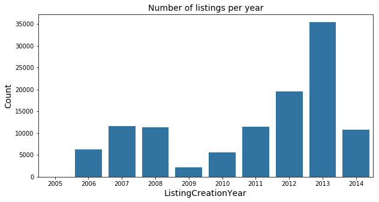

```python
# plot of listings per year
plot_bar(loan_df, 'ListingCreationYear', 'Number of listings per year')
```

The above bar plot shows that there was great decline in loan listing in 2009, followed by a continued growth up to 2013. There is an explanation for this, as seen on wikipedia

> "On November 24, 2008, the SEC found Prosper to be in violation of the Securities Act of 1933. As a result of these findings, the SEC imposed a cease and desist order on Prosper ... In July 2009, Prosper reopened their website for lending ("investing") and borrowing after having obtained SEC registration for its loans ("notes"). After the relaunch, bidding on loans was restricted to residents of 28 U.S. states and the District of Columbia. Borrowers may reside in any of 47 states, with residents of three states (Iowa, Maine, and North Dakota) not permitted to borrow through Prosper ... The lawsuit was settled July 19, 2013 for 10 million dollars paid in installments over three years."

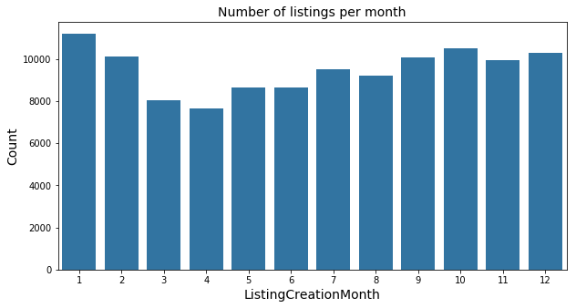

```python
# plot of average listing per month with the uncleaned data
plot_bar(loan_df, 'ListingCreationMonth', 'Number of listings per month')
```

There are more listing creation during the start and end of the year. But how true is this? To answer this we need to find why the number of listings dropped in 2014 and also take a look at the number of listings available for the months in each year. And as mentioned earlier, Proper Loan did take a time off from offering its services.

So, we will calculate the total number monthly listings for years where the data for all the 12 months of the year are available. These year from our cleanup are 2006, 2007, 2010, 2011 and 2013.

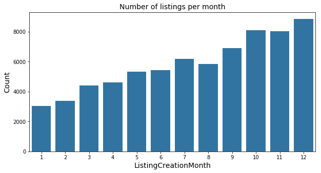

```python
plot_bar(month_not_missing, 'ListingCreationMonth', 'Number of listings per month')
```

The plot here is quite different from the initial one we plotted. Taking out the years with missing months gives a better picture of when listings where created. We see a trend, increasing from January to December.

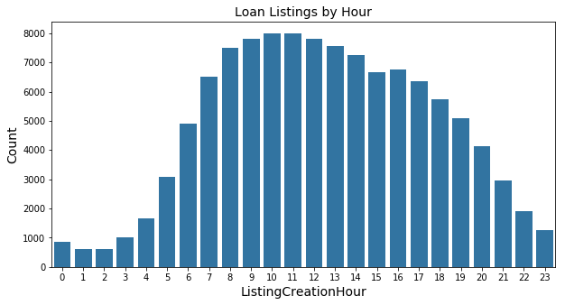

```python
# cleaning data of years with missing month we can see the distribution is well defined than before
plot_bar(loan_df, 'ListingCreationHour', 'Loan Listings by Hour')
```

Most listings were created during working hours. We see a trend increasing from the early mornings and decline towards late evenings.

## Loan Term

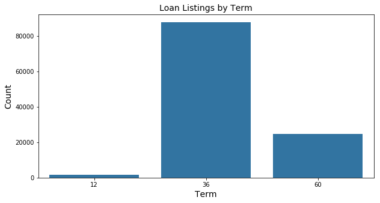

```python
# let's look at a plot of loan listing
plot_bar(loan_df, 'Term', 'Loan Listings by Term');
```

It seems like more borrowers opted for the 36 month term loan, and followed far behind by the 60 term loan. Quite a few number of borrowers took loans that takes 12 months to pay back. Let us view this in percentages.

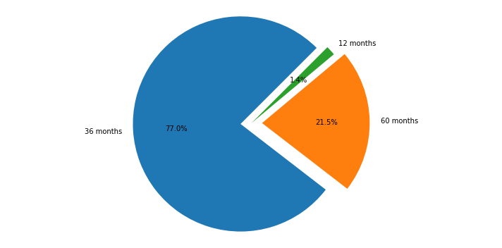

```python
#plot of pie chart of loan terms
labels = ['36 months', '60 months', '12 months']
explode = (0.1, 0.1, 0)
fig1, ax1 = plt.subplots()
ax1.pie(term_per, autopct='%1.1f%%', labels=labels, explode=explode, startangle=45)
# Equal aspect ratio ensures that pie is drawn as a circle
ax1.axis('equal')
plt.tight_layout()
plt.show()
```

We see that 77.04% of all the listings belong to the 36 month category.

## Prosper score

We will change this from numeric to categorical column and plot the count for each level.

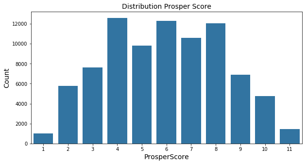

```python
# plot of prosper score distribution
plot_bar(prosper_score_df, 'ProsperScore', 'Distribution Prosper Score')
```

## Loan Original Amount

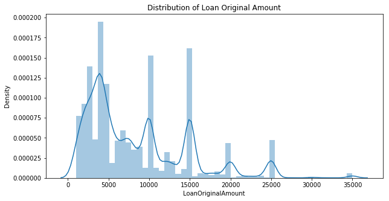

```python
#plot original loan amount
sns.distplot(loan_df.LoanOriginalAmount)
plt.ylabel('Density')
plt.title('Distribution of Loan Original Amount');
```

It seems like most borrowers prefer to take rounded amounts in 5s or 10s of thousands.

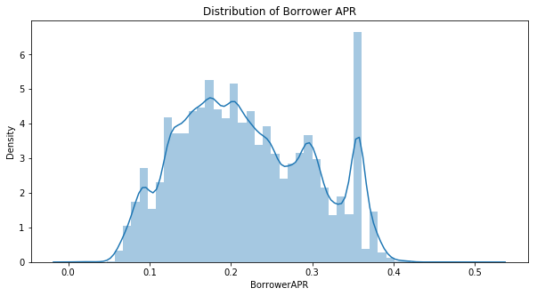

```python
# plot of brower apr distribution
sns.distplot(loan_df.BorrowerAPR[loan_df.BorrowerAPR.notnull()])
plt.title('Distribution of Borrower APR')
plt.ylabel('Density');
```

Most borrowers have an APR below 0.3. There is however a spike between 0.3 and 0.4

## Bivariate Analysis

In this section, We will try to find relation between some variables.

### Does high prosper score mean low borrower APR?

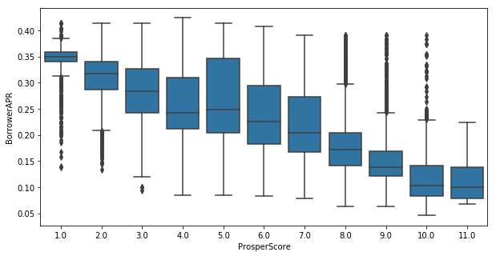

```python
# boxplot of prosperscore and BorrowerAPR
sns.boxplot(x='ProsperScore', y='BorrowerAPR', data=loan_df, color=base_color);
```

We see that as the prosper score increases, the BorrowerAPR decreases. This implies that borrowers with higher prospers score tend to pay lesser interest. But this is not always the case, the outliers in the box plot above shows that at a lesser ProsperScore level some borrower still paid lesser interest. Same occurence is spotted at higher Prosper Scores.

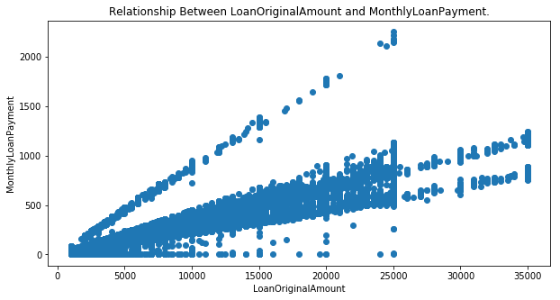

```python
# Scatter plot of Monthly loan payment and LoadOriginalAmount
plot_scatter(loan_df, 'LoanOriginalAmount', 'MonthlyLoanPayment')
```

There is a positive relationship between Loan Orinal Amount and Monthly Loan Payment.

### Multivariate Analysis

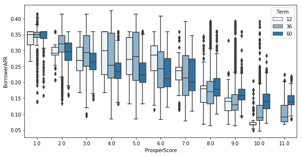

```python
# boxplot of prosperscore and BorrowerAPR
sns.boxplot(x='ProsperScore', y='BorrowerAPR', data=loan_df, color=base_color, hue='Term');
```

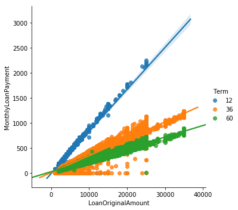

```python
# Scatter plot of Monthly loan payment and LoadOriginalAmount
sns.lmplot(x='LoanOriginalAmount', y='MonthlyLoanPayment', data=loan_df, hue='Term');
```

This shows that while there is correlation between LoanOriginalAmount and MonthlyLoanPayment, borrowers with shorter loan terms tend to have a higher MonthlyLoanPayment.

# Summary

Most loan listings were created during working hours. We see a trend increasing from the early mornings and decline towards late evenings.

We see that 77.04% of all the loan listings belong to the 36 month duration category.

There is correlation between LoanOriginalAmount and MonthlyLoanPayment, borrowers with shorter loan terms tend to have a higher MonthlyLoanPayment.